PUBPOL 543 Deliverable 1: Univariate plot

Note: The dataset used for this assignment was sourced from the US Government’s open data repository: https://catalog.data.gov/

Reading-in the data from the Github repository location:

```r
location='https://github.com/elenapopic543/Univariate/raw/main/'
file='Data_Breach_Notifications_Affecting_Washington_Residents.csv'
link=paste0(location,file)
data1 <- read.csv(file=url(link), header=TRUE, stringsAsFactors=FALSE)
```

Examining the variables in the dataframe:

```r
names(data1)
```

```
##  [1] "DateAware"                         "DateSubmitted"
##  [3] "DataBreachCause"                   "DateStart"
##  [5] "DateEnd"                           "Name"
##  [7] "Id"                                "CyberattackType"
##  [9] "WashingtoniansAffected"            "IndustryType"
## [11] "BusinessType"                      "Year"
## [13] "YearText"                          "WashingtoniansAffectedRange"
## [15] "BreachLifecycleRange"              "DaysToContainBreach"
## [17] "DaysToIdentifyBreach"              "DaysBreachLifecycle"
## [19] "DiscoveredInProgress"              "DaysOfExposure"
## [21] "DaysElapsedBetweenEndAndDiscovery" "EndedOnDayDiscovered"
## [23] "DaysElapsedBeforeNotification"     "DaysOfExposureRange"
```

Examining data types:

```r
str(data1,width = 70,strict.width='cut')
```

```
## 'data.frame':    823 obs. of  24 variables:
##  $ DateAware                        : chr  "07/16/2020 12:00:00 AM""..
##  $ DateSubmitted                    : chr  "09/14/2020 12:00:00 AM""..
##  $ DataBreachCause                  : chr  "Cyberattack" "Cyberatta"..
##  $ DateStart                        : chr  "09/24/2019 12:00:00 AM""..
##  $ DateEnd                          : chr  "11/14/2019 12:00:00 AM""..
##  $ Name                             : chr  "Baylor Genetics" "Natio"..
##  $ Id                               : int  10192 10176 10174 10172 9..
##  $ CyberattackType                  : chr  "Phishing" "Malware" "Ma"..
##  $ WashingtoniansAffected           : int  804 15556 1012 2785 1634 ..
##  $ IndustryType                     : chr  "Health" "Finance" "Busi"..
##  $ BusinessType                     : chr  "" "" "Retail" "Retail" ...
##  $ Year                             : int  2021 2021 2021 2021 2018 ..
##  $ YearText                         : int  2021 2021 2021 2021 2018 ..
##  $ WashingtoniansAffectedRange      : chr  "500-999" "10,000-49,999"..
##  $ BreachLifecycleRange             : chr  "200-299" "Unknown" "1-9"..
##  $ DaysToContainBreach              : int  0 NA 0 170 0 0 NA NA NA 0..
##  $ DaysToIdentifyBreach             : int  296 NA 99 917 0 151 NA NA..
##  $ DaysBreachLifecycle              : int  296 NA 99 1087 0 151 NA N..
##  $ DiscoveredInProgress             : chr  "false" "false" "false" "..
##  $ DaysOfExposure                   : int  51 NA 97 1087 0 82 260 NA..
##  $ DaysElapsedBetweenEndAndDiscovery: int  245 NA 2 NA NA 69 NA NA N..
##  $ EndedOnDayDiscovered             : chr  "false" "false" "false" "..
##  $ DaysElapsedBeforeNotification    : int  60 152 54 288 30 19 NA 28..
##  $ DaysOfExposureRange              : chr  "1-99" "Unknown" "1-99" "..
```

Examining raw values:

```r
head(data1$IndustryType,20)
```

```
##  [1] "Health"    "Finance"   "Business"  "Business"  "Business"  "Business"
##  [7] "Business"  "Business"  "Business"  "Business"  "Health"    "Business"
## [13] "Business"  "Education" "Health"    "Finance"   "Business"  "Business"
## [19] "Business"  "Business"
```

Creating a frequency table:

```r
absoluteT=table(data1$IndustryType,
                exclude = 'nothing')
absoluteT
```

```
##
##           Business          Education            Finance         Government
##                398                 70                105                 32
##             Health Non-Profit/Charity
##                125                 93
```

Transforming the counts into proportions:

```r
prop.table(absoluteT)
```

```
##
##           Business          Education            Finance         Government
##         0.48359660         0.08505468         0.12758202         0.03888214
##             Health Non-Profit/Charity
##         0.15188335         0.11300122
```

Translating proportions into percents:

```r
propT=prop.table(absoluteT)*100
propT
```

```
##
##           Business          Education            Finance         Government
##          48.359660           8.505468          12.758202           3.888214
##             Health Non-Profit/Charity
##          15.188335          11.300122
```

Turning the frequency table into a dataframe:

```r
(tableFreq=as.data.frame(absoluteT))
```

```
##                 Var1 Freq
## 1           Business  398
## 2          Education   70
## 3            Finance  105
## 4         Government   32
## 5             Health  125
## 6 Non-Profit/Charity   93
```

Renaming columns and adding percents:

```r
names(tableFreq)=c("Industry","Count")
# adding percents:
tableFreq$Percent=as.vector(propT)

tableFreq
```

```
##             Industry Count   Percent
## 1           Business   398 48.359660
## 2          Education    70  8.505468
## 3            Finance   105 12.758202
## 4         Government    32  3.888214
## 5             Health   125 15.188335
## 6 Non-Profit/Charity    93 11.300122
```

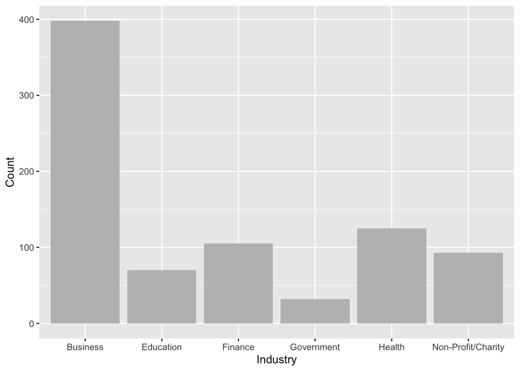

```r
library(ggplot2)
#Creating the base object:
base = ggplot(data = tableFreq,
             aes(x = Industry,
                 y = Count))
#Adding layers to create default barplot:
plot1 = base + geom_bar(fill ="gray",
                        stat = 'identity')
plot1
```

Adding titles:

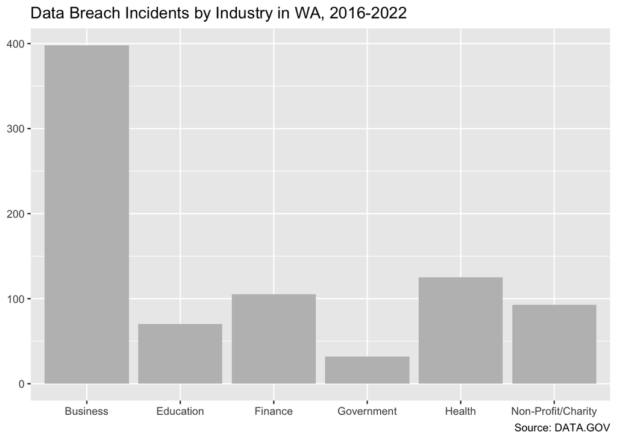

```r
titleText='Data Breach Incidents by Industry in WA, 2016-2022'
sourceText='Source: DATA.GOV'

plot2 = plot1 + labs(title=titleText,
                     x =NULL,
                     y = NULL,
                     caption = sourceText)
plot2
```

Using percent values instead of counts on Y-axis:

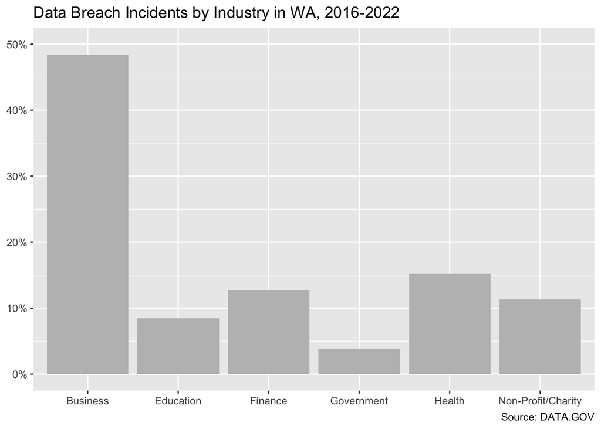

```r
base= ggplot(data = tableFreq,
             aes(x = Industry,
                 y = Percent))

plot1 = base + geom_bar(fill ="gray",
                        stat = 'identity')

plot2 = plot1 + labs(title=titleText,
                     x =NULL,
                     y = NULL,
                     caption = sourceText)
#Customizing the axes:
library(scales)
plot3 = plot2 + scale_y_continuous(breaks=c(0,10,20,30,40,50),
                                   limits = c(0,50),
                                   labels=unit_format(suffix = '%'))
plot3
```

Adding the actual percent values (rounded to two decimal places):

```r
paste0(round(tableFreq$Percent,2), '%')
```

```
## [1] "48.36%" "8.51%"  "12.76%" "3.89%"  "15.19%" "11.3%"
```

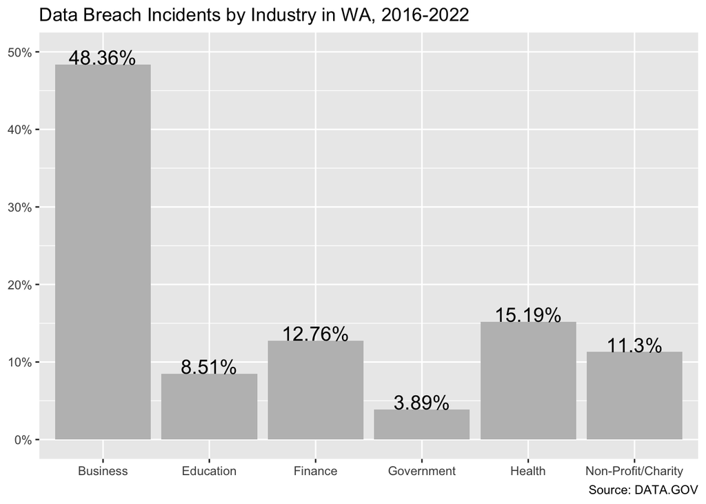

```r
LABELS=paste0(round(tableFreq$Percent,2), '%')

plot4 = plot3 + geom_text(vjust=0,
                          size = 5,
                          aes(y = Percent,
                          label = LABELS))
plot4
```

Ordering the bars by height:

```r
tableFreq=tableFreq[order(tableFreq$Percent),]
tableFreq
```

```
##             Industry Count   Percent
## 4         Government    32  3.888214
## 2          Education    70  8.505468
## 6 Non-Profit/Charity    93 11.300122
## 3            Finance   105 12.758202
## 5             Health   125 15.188335
## 1           Business   398 48.359660
```

Saving the order:

```r
(industriesOrd=tableFreq[order(tableFreq$Percent),'Industry'])
```

```
## [1] Government         Education          Non-Profit/Charity Finance
## [5] Health             Business
## Levels: Business Education Finance Government Health Non-Profit/Charity
```

Finalizing the barplot:

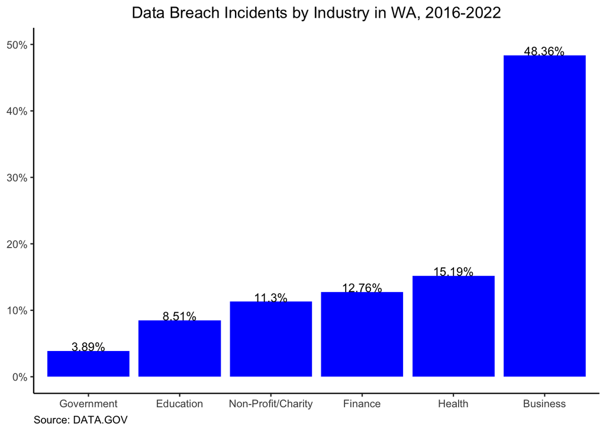

```r
#Generating values for column labels
LABELS = paste0(round(tableFreq$Percent,2), '%')
#Specifying the base of the plot
base = ggplot(data = tableFreq,
             aes(x = Industry,y = Percent))
#Ordering the bars by height:
base = base + scale_x_discrete(limits=industriesOrd)
#Changing the theme to classic
base = base + theme_classic()
#Adding layers to the base
plot1 = base + geom_bar(fill ="blue1",
                        stat = 'identity')
#Adding title and caption
plot2 = plot1 + labs(title=titleText,
                     x =NULL,
                     y = NULL,
                     caption = sourceText)
#Customizing and labeling the values on the Y-axis with a % suffix:
plot3 = plot2 + scale_y_continuous (breaks=c(0,10,20,30,40,50),
                                   limits = c(0,50),
                                   labels=unit_format(suffix = '%'))
#Moving the plot title to the center, and caption to left:
plot4 = plot3 + theme(plot.caption = element_text(hjust = 0),
                      plot.title = element_text(hjust = 0.5))

#Adding column labels
plot5 = plot4 + geom_text(vjust=0,
                          size = 3.5,
                          aes(y = Percent,
                          label = LABELS))
plot5
```

Deliverable 2: Bivariate Plot In the following, We will explore the number of Washingtonians affected in data breaches by the type of the industry where data breach incidents occurred (i.e., perform a Categorical-Numerical bivariate relationship analysis)

Summarizing the variable reflecting the number of people affected by the data breach:

```r
summary(data1$WashingtoniansAffected)
```

```
##    Min. 1st Qu.  Median    Mean 3rd Qu.    Max.    NA's
##      15     814    1609   27652    5266 3243664      31
```

Excluding the missing values:

```r
#data1_nona=data1[complete.cases(data1),]
```

Getting the median of exposed residents for each industry type:

```r
aggregate(data=data1, WashingtoniansAffected~IndustryType,median)
```

```
##         IndustryType WashingtoniansAffected
## 1           Business                 1408.5
## 2          Education                 2015.5
## 3            Finance                 1511.0
## 4         Government                 2249.0
## 5             Health                 2162.0
## 6 Non-Profit/Charity                 2384.0
```

Getting the mean of exposed residents for each industry type:

```r
aggregate(data=data1, WashingtoniansAffected~IndustryType,mean)
```

```
##         IndustryType WashingtoniansAffected
## 1           Business               15512.78
## 2          Education               19259.59
## 3            Finance               45406.81
## 4         Government              115392.45
## 5             Health               29040.06
## 6 Non-Profit/Charity               31217.84
```

Checking other statistics:

```r
# using "summary" function
tapply(data1$WashingtoniansAffected,
       data1$IndustryType, summary)
```

```
## $Business
##    Min. 1st Qu.  Median    Mean 3rd Qu.    Max.    NA's
##      15     745    1408   15513    4094 2079648      26
##
## $Education
##    Min. 1st Qu.  Median    Mean 3rd Qu.    Max.    NA's
##     505    1062    2016   19260    5148  769088       2
##
## $Finance
##    Min. 1st Qu.  Median    Mean 3rd Qu.    Max.
##     518     823    1511   45407    4255 3243664
##
## $Government
##    Min. 1st Qu.  Median    Mean 3rd Qu.    Max.    NA's
##     532    1095    2249  115392   11700 1449645       1
##
## $Health
##    Min. 1st Qu.  Median    Mean 3rd Qu.    Max.    NA's
##     505     892    2162   29040   12538  628569       2
##
## $`Non-Profit/Charity`
##    Min. 1st Qu.  Median    Mean 3rd Qu.    Max.
##     500    1015    2384   31218    8169  981068
```

The above summary statistics point out that half of the data breach incidents in each industry type are affecting from roughly 1400 to 2400 WA residents. The incidents with a large number of exposed people are less common in each industry type. We will reflect these findings in the following boxplot:

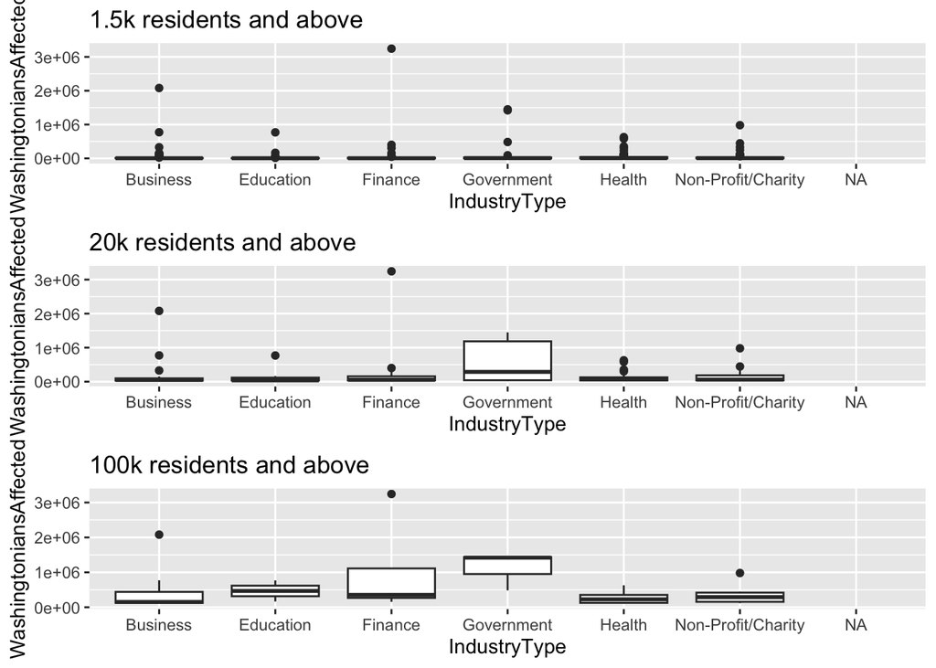

```r
library(ggpubr)

base1=ggplot(data=data1[data1$WashingtoniansAffected>=1500,],
            aes(x=IndustryType,y=WashingtoniansAffected))
box1=base1 + geom_boxplot() + labs(title = "1.5k residents and above")

base2=ggplot(data=data1[data1$WashingtoniansAffected>=20000,],
            aes(x=IndustryType,y=WashingtoniansAffected))
box2=base2 + geom_boxplot() + labs(title = "20k residents and above")

base3=ggplot(data=data1[data1$WashingtoniansAffected>=100000,],
            aes(x=IndustryType,y=WashingtoniansAffected))
box3=base3 + geom_boxplot() + labs(title = "100k residents and above")

ggarrange(box1,box2,box3,ncol = 1)
```

Moving forward, we will focus our analysis on data breach incidents that affected 100k people or more.

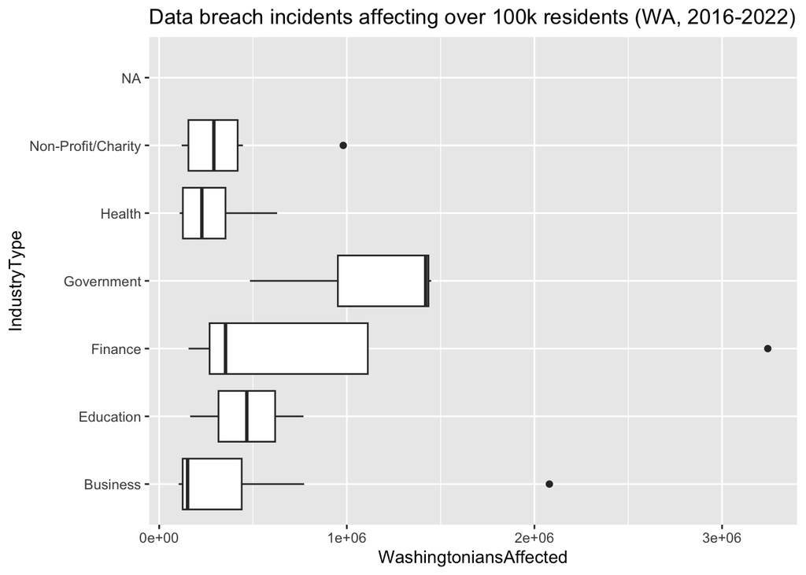

```r
titleText2="Data breach incidents affecting over 100k residents (WA, 2016-2022)"
base4=ggplot(data=data1[data1$WashingtoniansAffected>=100000,],
            aes(x=IndustryType,y=WashingtoniansAffected))
box4=base4 + geom_boxplot() +
    labs(title = titleText2)
box4 + coord_flip()
```

Reordering by the median value of incidents:

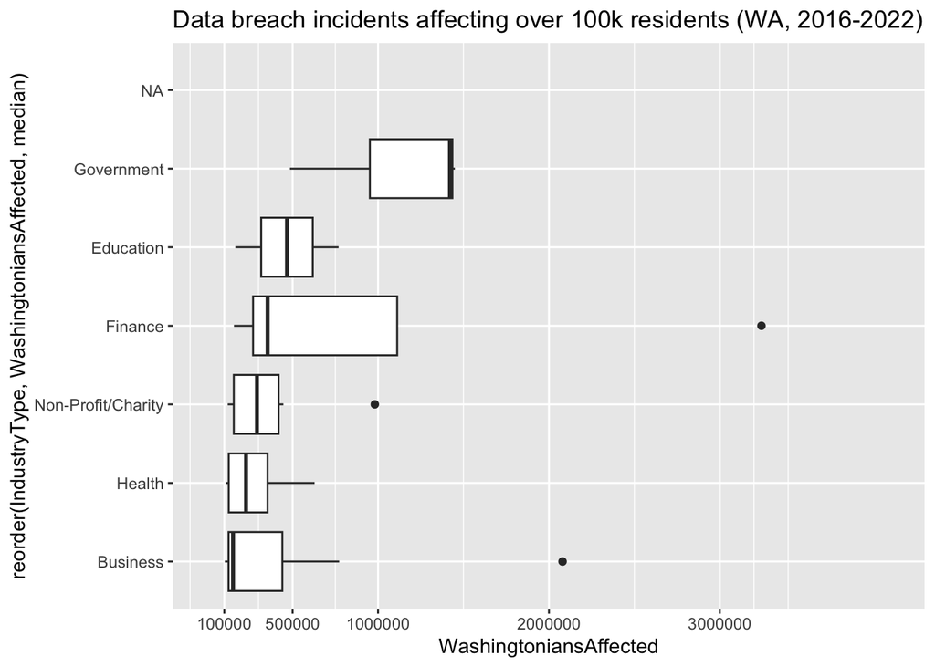

```r
base5=ggplot(data=data1[data1$WashingtoniansAffected>=100000,],
            aes(x=reorder(IndustryType,
                          WashingtoniansAffected,
                          median),
                y=WashingtoniansAffected))
box5=base5 + geom_boxplot() + labs(title =titleText2) + scale_y_continuous (breaks=c(100000,500000,1000000,2000000,3000000),
limits = c(0,4000000),
labels = c("100000","500000","1000000","2000000","3000000"))

box5  + coord_flip()
```

Creating a histogram:

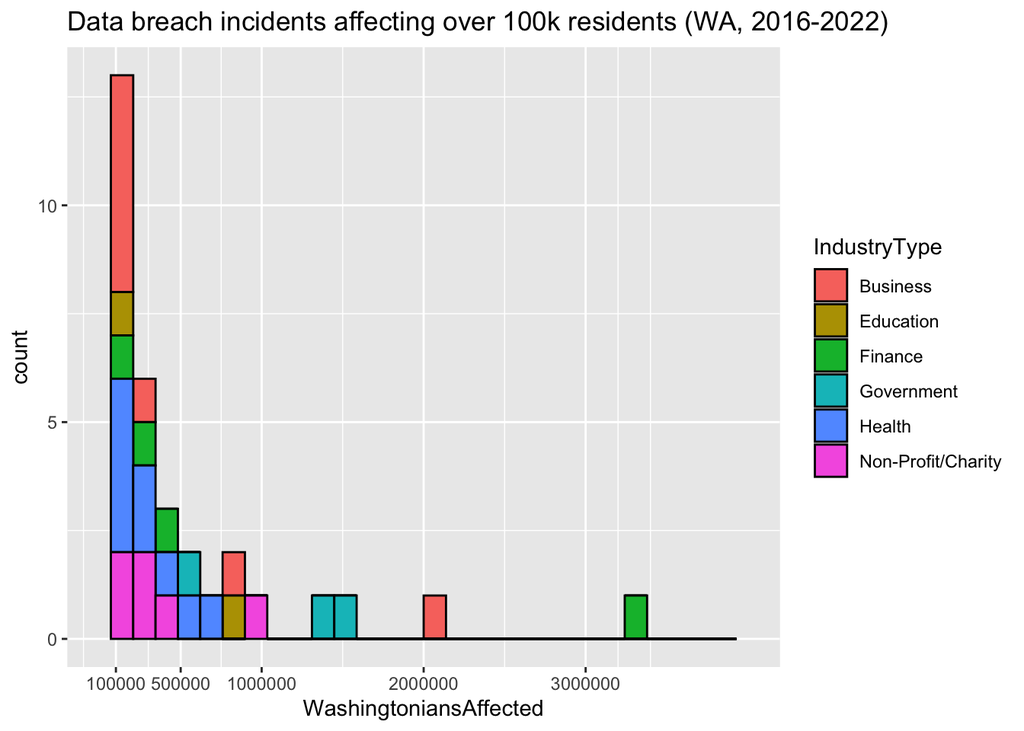

```r
baseHY=ggplot(data=data1[data1$WashingtoniansAffected>=100000,],
            aes(x=WashingtoniansAffected))
histHY=baseHY + geom_histogram(aes(fill=IndustryType),
                              color='black') +
  scale_x_continuous(breaks=c(100000,500000,1000000,2000000,3000000),
limits = c(0,4000000),
labels = c("100000","500000","1000000","2000000","3000000")) + labs(title =titleText2)

histHY
```

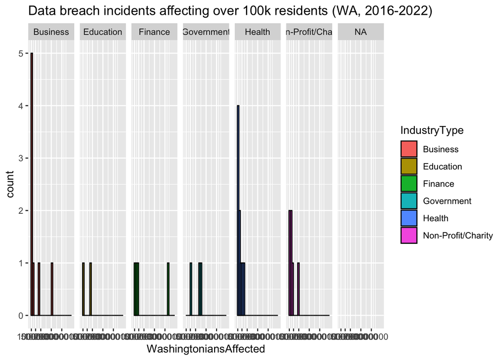

```r
#Adding facets and further customizing the axes of the plot:
baseHY=ggplot(data=data1[data1$WashingtoniansAffected>=100000,],
            aes(x=WashingtoniansAffected))
histHY=baseHY + geom_histogram(aes(fill=IndustryType),
                              color='black') + labs(title =titleText2) +
scale_x_continuous(breaks=c(100000,500000,1000000,2000000,3000000),
limits = c(0,4000000),
labels = c("100000","500000","1000000","2000000","3000000"))

histHY + facet_grid(~IndustryType)
```

Alternative:

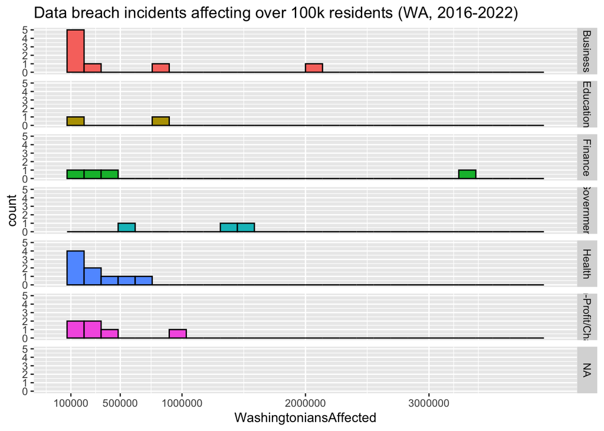

```r
histHY + facet_grid(IndustryType~.) + guides(fill="none")
```

Creating a mean-error plot:

```r
data1[,c('IndustryType', 'WashingtoniansAffected')] %>%head(20)
```

```
##    IndustryType WashingtoniansAffected
## 1        Health                    804
## 2       Finance                  15556
## 3      Business                   1012
## 4      Business                   2785
## 5      Business                   1634
## 6      Business                   5013
## 7      Business                    774
## 8      Business                     NA
## 9      Business                   1100
## 10     Business                  21687
## 11       Health                   2876
## 12     Business                   2671
## 13     Business                    768
## 14    Education                     NA
## 15       Health                     NA
## 16      Finance                   2545
## 17     Business                     NA
## 18     Business                    604
## 19     Business                    661
## 20     Business                     NA
```

```r
library(lattice)
library(plyr)
Rmisc::group.CI(data=data1,
          WashingtoniansAffected~IndustryType)
```

```
##         IndustryType WashingtoniansAffected.upper WashingtoniansAffected.mean
## 1           Business                     27452.21                    15512.78
## 2          Education                     42242.02                    19259.59
## 3            Finance                    107211.90                    45406.81
## 4         Government                    248507.11                   115392.45
## 5             Health                     45166.87                    29040.06
## 6 Non-Profit/Charity                     55675.95                    31217.84
##   WashingtoniansAffected.lower
## 1                     3573.346
## 2                    -3722.841
## 3                   -16398.277
## 4                   -17722.205
## 5                    12913.240
## 6                     6759.728
```

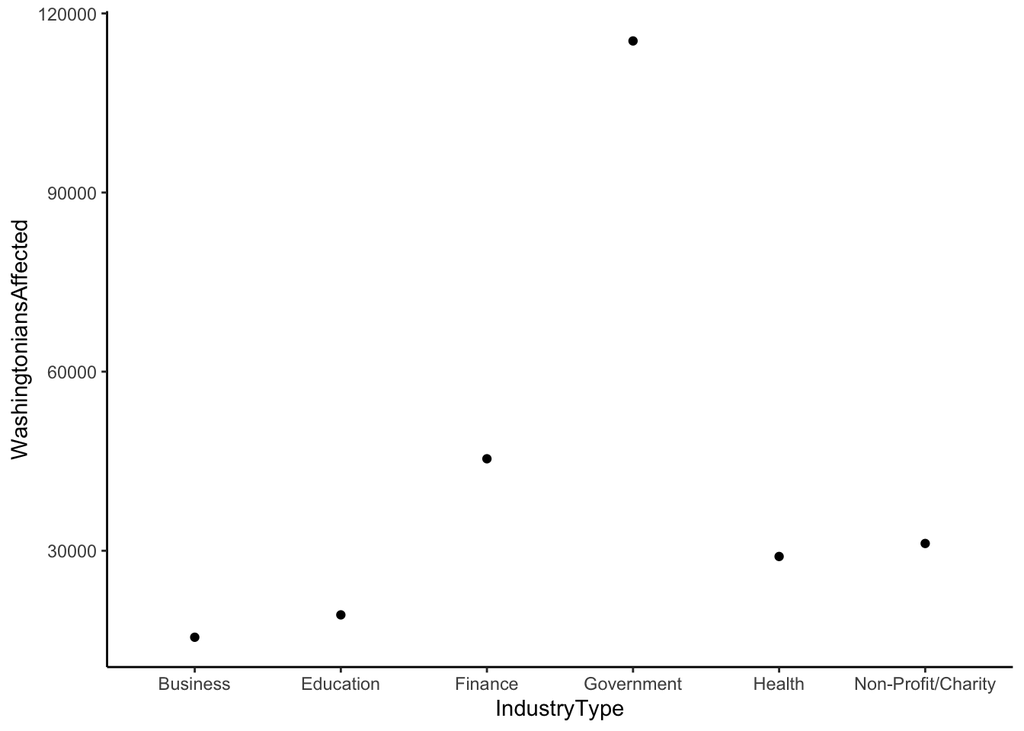

```r
baseMEANs=ggplot(data1, aes(x=IndustryType,
                             y=WashingtoniansAffected)) +
        theme_classic()
pointMEANS=baseMEANs + stat_summary(fun = mean,
                                    geom = "point")
pointMEANS
```

Adding an error-bar:

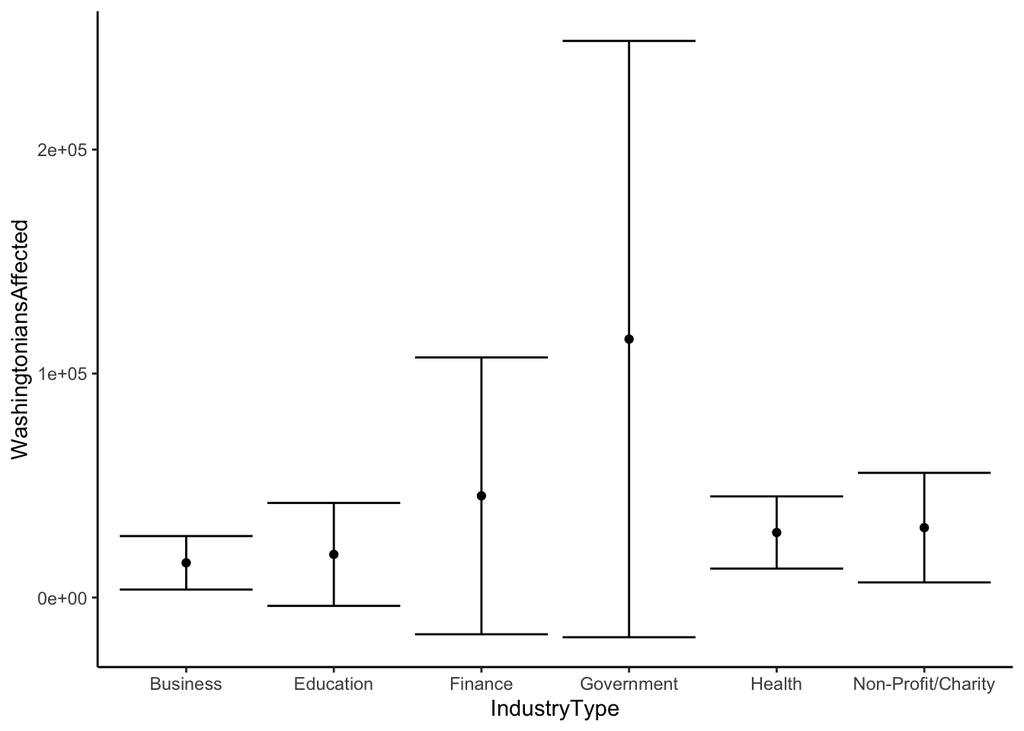

```r
pointErrors=pointMEANS + stat_summary(fun.data = mean_ci,
                                      geom = "errorbar")
pointErrors
```

Including the data in a plot:

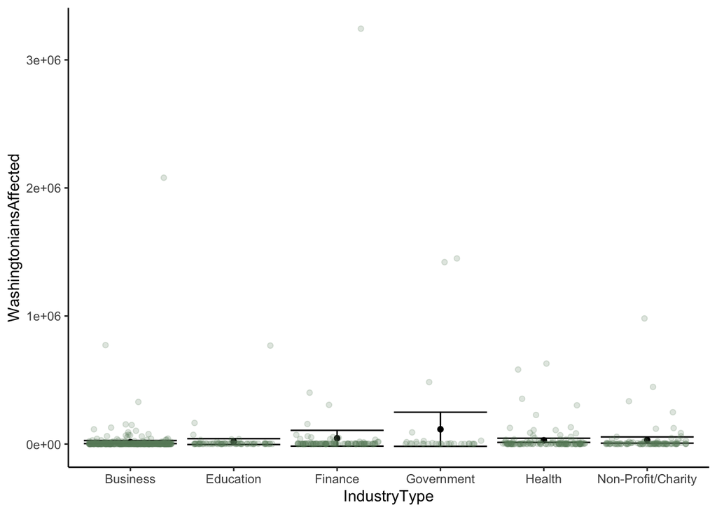

```r
BarJit=pointErrors + geom_jitter(colour="darkseagreen4",
                             alpha=0.2 #transparency
                             )
BarJit
```